# Eksploracja Krajowych planów na rzecz energii i klimatu

## Co wyniknęło z eksploracji?

- Głównym krokiem przed eksploracją było przetworzenie danych w odpowiedni sposób. Uwzględniona została przy tym zakładana struktura dokumentów. Okazało się, że rzeczywiście występują istotne różncie pomiędzy poszczególnymi sekcjami i wymiarami, zatem analiza w podziale na składowe dokumentu ma sens.
- Okazało się również, że w danych widać różnice pomiędzy dokumentami poszczególnych państw, co także stanowi dobry znak dla dalszej pracy zakładającej dokładniejsze porównania między poszczególnymi członkami UE.
- Pojawiły się kolejne pytania badawcze, np. dotyczące różnic w traktowaniu o transporcie w procesie dekarbonizacji.
- Zidentyfikowano słowa, które należy rozważyć w kontekście uwzględnienia jako stop-słowa.
- Wskazano dalsze kroki: próba poprawy odczytu tekstów z PDF (bez tabel, wykresów, numeracji stron)

## Importy

```python
from google.colab import drive
drive.mount('/content/drive')
```

```python
!python -m spacy download en_core_web_md
# trzeba uruchomić ponownie środowisko wykonawcze po pobraniu
```

```python
# !pip install PyPDF2
# from PyPDF2 import PdfFileReader
```

```python
! pip install swifter
! pip install matplotlib==3.4.0
! pip install textacy
! pip install thinc
```

```python
import pandas as pd
import numpy as np
import spacy
```

```python
en = spacy.load("en_core_web_md")
```

```python
import os
import swifter
import pickle
from collections import Counter
from tqdm import tqdm
import seaborn as sns
import matplotlib.pyplot as plt
sns.set_theme(style="whitegrid")
```

```python
DIR = '/content/drive/MyDrive/NLP-klimat/'
```

## Analiza

### Wczytanie danych

Teksty zostały odczytane z PDF-ów na podstawie wcześniejszego otagowania poszczególnych dokumentów.

```python
NECP_annotations = pd.read_csv(DIR+'NECP.txt')
```

```python
NECP_annotations = NECP_annotations.replace({"None": None})
```

Tagowanie odbywało się ręcznie poprzez przegląd dokumentów i oznaczenie odpowiednich sekcji (więcej o sekcjach później, w rozdziale o analizach).

```python
NECP_annotations
```

|  | country | file_name | subsection | energy_union_dimension | start_page | end_page | start_text | end_text |
| --- | --- | --- | --- | --- | --- | --- | --- | --- |
| 0 | Austria | at_final_necp_main_en_0.pdf | Overview and Process for Establishing the Plan | None | 6 | 70 | None | None |
| 1 | Austria | at_final_necp_main_en_0.pdf | National Objectives and Targets | Decarbonisation | 71 | 83 | None | 2040 |
| 2 | Austria | at_final_necp_main_en_0.pdf | National Objectives and Targets | Energy efficiency | 83 | 88 | 2.2. | NECP |
| 3 | Austria | at_final_necp_main_en_0.pdf | National Objectives and Targets | Energy security | 88 | 90 | 2.3. | None |
| 4 | Austria | at_final_necp_main_en_0.pdf | National Objectives and Targets | Internal market | 91 | 98 | None | efficiency |
| ... | ... | ... | ... | ... | ... | ... | ... | ... |
| 454 | Slovakia | sk_final_necp_main_en_0.pdf | Current Situation and Reference Projections | Energy efficiency | 175 | 188 | 4.3 | reports |
| 455 | Slovakia | sk_final_necp_main_en_0.pdf | Current Situation and Reference Projections | Energy security | 188 | 196 | 4.4 | capacity |
| 456 | Slovakia | sk_final_necp_main_en_0.pdf | Current Situation and Reference Projections | Internal market | 196 | 214 | 4.5 | document |
| 457 | Slovakia | sk_final_necp_main_en_0.pdf | Current Situation and Reference Projections | R&I and Competitiveness | 214 | 224 | 4.6 | None |
| 458 | Slovakia | sk_final_necp_main_en_0.pdf | Impact Assessment of Planned Policies and Meas... | None | 225 | 251 | None | None |

459 rows × 8 columns

```python
def read_NECPs(annotations_df, result_texts_list):
  for i, row in annotations_df.iterrows():
    if row.start_page is None:
      result_texts_list.append(None)
      continue
    start_page = int(row.start_page)
    end_page = int(row.end_page)
    print(f"Row {i} - reading {int(end_page-start_page+1)} pages from file: {row.file_name}; subsection: {row.subsection}, dimension: {row.energy_union_dimension}")
    if i > 0:
      if row.file_name != current_file_name:
        current_file_name = row.file_name
    else:
      current_file_name = row.file_name
    file = open(DIR+'Final NECPs received/'+current_file_name, 'rb')
    fileReader = PdfFileReader(file)
    text = ""
    count = start_page-1
    while count < end_page:
      pageObj = fileReader.getPage(count)
      count += 1
      text += pageObj.extractText().replace("\n", "")
    if row.start_text is not None:
      text = row.start_text+text.split(row.start_text, 1)[1]
    if row.end_text is not None:
      text = text.rsplit(row.end_text, 1)[0]+row.end_text
    result_texts_list.append(text)
  return result_texts_list
```

```python
all_texts = []
```

```python
all_texts = read_NECPs(NECP_annotations, all_texts)
```

```python
NECP_annotations["text"] = all_texts
```

```python
NECP_annotations.to_csv("necp_processed.csv")
```

### Wstęp do analizy NECP

#### Intro: czym jest NECP?

**NECP** - National Energy and Climate Plan (Krajowy plan na rzecz energii i klimatu)

Aby zrealizować ustanowione przez Unię Europejską cele w zakresie energii i klimatu na 2030 rok, państwa członkowskie zostały zobowiązane do ustanowienia 10-letniego planu na rzecz energii i klimatu na okres od 2021 do 2030 roku (NECP).

**Struktura NECP**

[figure not shown]

Zatem dla każdego z 27 państw członkowskich otrzymujemy sekcje:

- Overview and Process for Establishing the Plan - Zarys ogólny i proces opracowywania planu
- National Objectives and Targets - Krajowe założenia i cele
- Policies and Measures - Polityki i działania
- Current Situation and Reference Projections - Aktualna sytuacja i prognozy z obecną polityką klimatyczną
- Impact Assessment of Planned Policies and Measures - Ocena wpływu planowanych działań na rzecz klimatu

Według wzorcowej struktury sekcje 2-5 powinny byc podzielone na 5 wymiarów:

- Decarbonisation - Obniżenie emisyjności
- Energy efficiency - Efektywność energetyczna
- Energy security - Bezpieczeństwo energetyczne
- Internal market - Wewnętrzny rynek energii
- R&I and Competitiveness - Badania naukowe, innowacje i konkurencyjność

W rzeczywistości w większości planów w sekcji oceny wpływu planowanych działań na rzecz klimatu nie ma podziału na 5 wymiarów

```python
necp_processed = pd.read_csv(DIR+'necp_processed.csv', index_col = 0)
```

Kolumny zaimportowanej ramki danych.

```python
necp_processed.columns
```

```
Index(['country', 'file_name', 'subsection', 'energy_union_dimension',
       'start_page', 'end_page', 'start_text', 'end_text', 'text'],
      dtype='object')
```

Kolumny 'start_page', 'end_page', 'start_text', 'end_text' służyły jedynie do poprawnego wczytania dokumentów z PDF-ów, zatem możemy się ich pozbyć.

```python
necp_processed.drop(['start_page', 'end_page', 'start_text', 'end_text'], axis = 1, inplace = True)
```

Przyjrzyjmy się brakom danych.

```python
necp_processed.info()
```

```
<class 'pandas.core.frame.DataFrame'>
Int64Index: 459 entries, 0 to 458
Data columns (total 5 columns):
 #   Column                  Non-Null Count  Dtype
---  ------                  --------------  -----
 0   country                 459 non-null    object
 1   file_name               459 non-null    object
 2   subsection              459 non-null    object
 3   energy_union_dimension  405 non-null    object
 4   text                    453 non-null    object
dtypes: object(5)
memory usage: 21.5+ KB
```

Nie każda z sekcji jest podzielona na wymiary, zatem braki danych w kolumnie 'energy_union_dimension' są uzasadnione. Przyjrzyjmy się rekordom, w których brakuje tesktu.

```python
necp_processed.loc[necp_processed.isnull()["text"]]
```

|  | country | file_name | subsection | energy_union_dimension | text |
| --- | --- | --- | --- | --- | --- |
| 244 | Latvia | lv_final_necp_main_en_0.pdf | Policies and Measures | Decarbonisation | NaN |
| 317 | Greece | el_final_necp_main_en_0.pdf | Current Situation and Reference Projections | Decarbonisation | NaN |
| 318 | Greece | el_final_necp_main_en_0.pdf | Current Situation and Reference Projections | Energy efficiency | NaN |
| 319 | Greece | el_final_necp_main_en_0.pdf | Current Situation and Reference Projections | Energy security | NaN |
| 320 | Greece | el_final_necp_main_en_0.pdf | Current Situation and Reference Projections | Internal market | NaN |
| 321 | Greece | el_final_necp_main_en_0.pdf | Current Situation and Reference Projections | R&I and Competitiveness | NaN |

```python
necp_processed.loc[(necp_processed["country"] == "Greece") & (necp_processed["subsection"] == "Current Situation and Reference Projections")]
```

|  | country | file_name | subsection | energy_union_dimension | text |
| --- | --- | --- | --- | --- | --- |
| 317 | Greece | el_final_necp_main_en_0.pdf | Current Situation and Reference Projections | Decarbonisation | NaN |
| 318 | Greece | el_final_necp_main_en_0.pdf | Current Situation and Reference Projections | Energy efficiency | NaN |
| 319 | Greece | el_final_necp_main_en_0.pdf | Current Situation and Reference Projections | Energy security | NaN |
| 320 | Greece | el_final_necp_main_en_0.pdf | Current Situation and Reference Projections | Internal market | NaN |
| 321 | Greece | el_final_necp_main_en_0.pdf | Current Situation and Reference Projections | R&I and Competitiveness | NaN |

Plan klimatyczny Grecji nie zawiera wydzielonej sekcji o aktualnej sytuacji i prognozach z obecną polityką klimatyczną. Łotwa nie ma wymiaru o obniżeniu emisyjności w sekcji Politylki i działań. Rekordy te nie przenoszą żadnej informacji. Można się ich pozbyć.

```python
necp_processed.drop(necp_processed[necp_processed.isnull()["text"]].index, axis = 0, inplace = True)
```

```python
len(necp_processed)
```

```
453
```

Zostało 453 części dokumentów.

##### Przetworzenie tekstów

```python
tqdm.pandas()
necp_docs = necp_processed['text'].swifter.apply(en)
```

```python
# eksport przetworzonych dokumentów
with open(DIR + 'necp_docs.pickle', 'wb') as f:
  pickle.dump(necp_docs, f)
```

##### Wczytanie

```python
# import przetworzonych dokumentów
with open(DIR + 'necp_docs.pickle', 'rb') as f:
    necp_docs = pickle.load(f)
```

### Analiza ilościowa

#### Długość dokumentów

liczona jako liczba słów w dokumencie

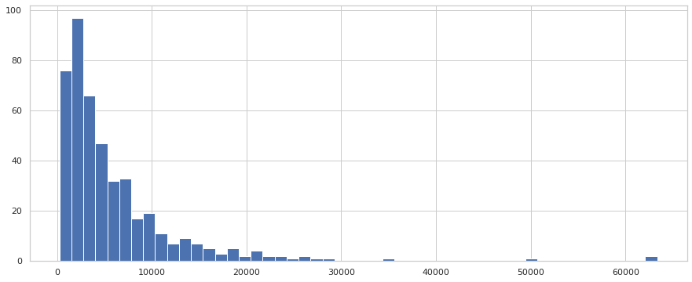

```python
from matplotlib import pyplot as plt

plt.figure(figsize=(15,6))
necp_processed["length"] = necp_docs.str.len()

necp_processed["length"].hist(bins = 50)
plt.show()
```

Większość wydzielonych części dokumentów ma mniej niż 20 tysięcy słów. Przyjrzyjmy się wyjątkowo długim tekstom.

```python
necp_processed.loc[necp_processed["length"] > 30000][["country", "file_name", "subsection", "energy_union_dimension", "length"]]
```

|  | country | file_name | subsection | energy_union_dimension | length |
| --- | --- | --- | --- | --- | --- |
| 23 | Belgium | be_final_necp_parta_en_0.pdf | Policies and Measures | Decarbonisation | 63341 |
| 24 | Belgium | be_final_necp_parta_en_0.pdf | Policies and Measures | Energy efficiency | 49678 |
| 227 | Lithuania | lt_final_necp_main_en_0.pdf | Policies and Measures | Decarbonisation | 35289 |
| 373 | Poland | pl_final_necp_part_5_en_0.pdf | Impact Assessment of Planned Policies and Meas... | NaN | 63111 |

Najdłuższe części (powyżej 30000 słów) to wybrane wymiary polityki i działań w planach Belgii i Litwy oraz sekcja oceny wpływu planowanych działań w Polsce.

Przyjrzyjmy się, czy można zaobserwować różnice w długościach poszczególnych sekcji/wymiarów.

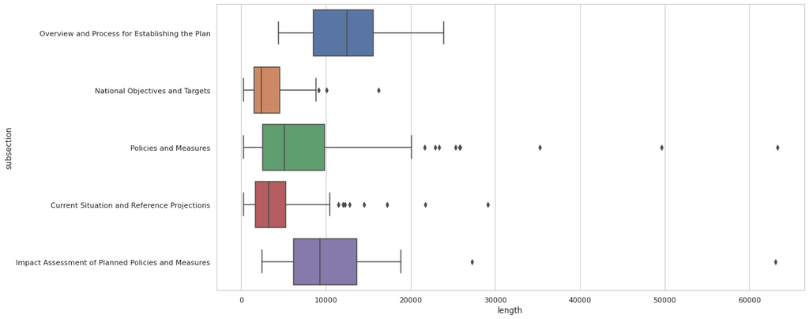

```python
plt.figure(figsize=(16, 8))
sns.boxplot(y='subsection', x='length', data=necp_processed)
plt.show()
```

Wyraźnie dłuższe są sekcje *Overview...* i *Impact...*, co ma jednak związek z tym, że dokumenty do nich należące nie są dzielone na zdefiniowane wymiary. Natomiast spośród sekcji dzielonych na wyniary, najdłuższe dokumenty dotyczą polityk i środków.

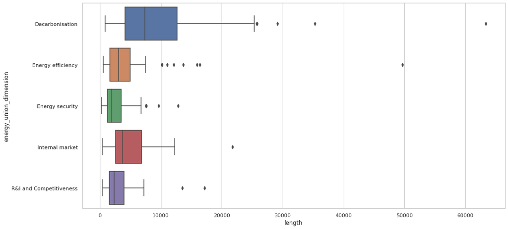

```python
plt.figure(figsize=(16, 8))
sns.boxplot(y='energy_union_dimension', x='length', data=necp_processed)
plt.show()
```

Analizując poszczególne wymiary, widzimy, że najwięcej uwagi jest poświęcanej emisyjności - dekarbonizacji. Stosunkowo krótsze od pozostałych są rozdziały poświęcone bezpieczeństwu energetycznemu i researchowi.

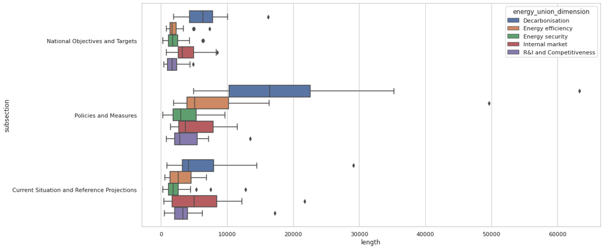

```python
plt.figure(figsize=(16, 8))
sns.boxplot(hue='energy_union_dimension', x='length', y='subsection',
            data=necp_processed[~necp_processed.subsection.isin(
                ['Overview and Process for Establishing the Plan',
                'Impact Assessment of Planned Policies and Measures'])])
plt.show()
```

Obserwacje odnośnie różnic w długości potwierdzają się też kiedy popatrzymy na hierarchiczne pogrupowanie - najdluższe teksty są związane z Policies and Measures, przy czym to dekarbonizacja zajmuej najwięcej uwagi.

#### Najczęstsze słowa

```python
def plot_counter(counter: Counter, orient: str = 'h', color: str='lightblue', figsize: tuple=(20,13)):
  plt.figure(figsize=figsize)
  keys = [k[0] for k in counter]
  vals = [int(k[1]) for k in counter]
  ax = sns.barplot(x=vals, y=keys, orient=orient, color=color)
  ax.bar_label(ax.containers[0])
  return ax
```

```python
necp_processed["necp_lemmas"] = necp_docs.apply(lambda doc: [token.lemma_ for token in doc if not token.is_stop if not token.is_punct if token.is_alpha])
necp_lemmas_counter = Counter(necp_processed["necp_lemmas"].sum()).most_common(30)
```

##### **Top 30 najczęstszych słów**

- we wszystkich dokumentach
- po lematyzacji

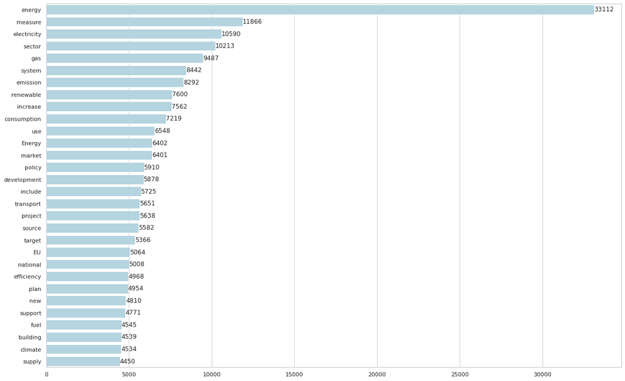

```python
plot_counter(necp_lemmas_counter)
plt.show()
```

Widzimy słowa, które ze względu na specyfikę tekstu będą się częściej powtarzać. Nie bierzmy ich pod uwagę w dalszej analizie - to pierwsi kandydaci na stop-słowa.

```python
extra_stop_words =  ['energy', 'Energy', 'measure', 'electricity', 'sector', 'EU',
                     'system', 'market' ,'national', 'plan', 'project', 'use']
necp_processed["necp_lemmas"] = necp_docs.apply(lambda doc: [token.lemma_ for token in doc if not token.is_stop if not token.is_punct if token.is_alpha if not (token.lemma_ in extra_stop_words)])
necp_lemmas_counter2 = Counter(necp_processed["necp_lemmas"].sum())
```

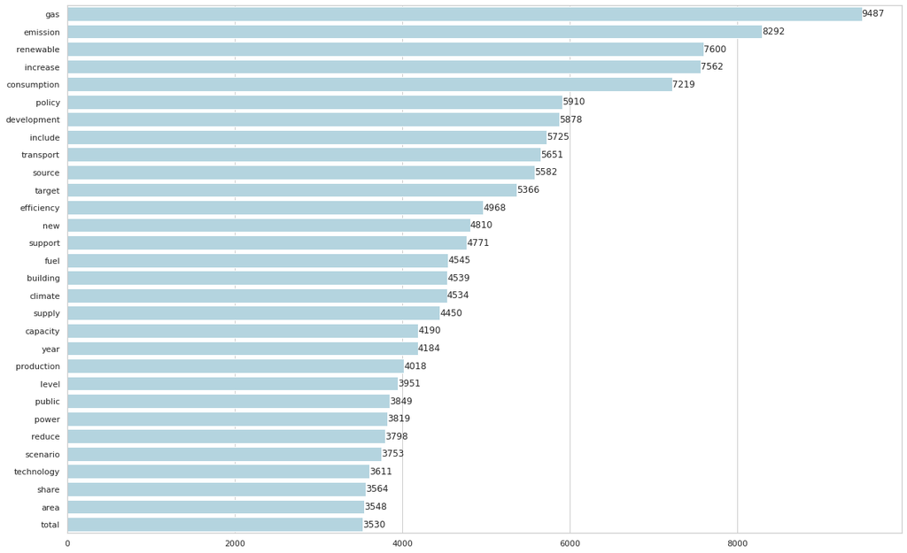

```python
plot_counter(necp_lemmas_counter2.most_common(30))
plt.show()
```

Najczęściej występują takie słowa jak 'gas', 'emission', 'renewable'. Nie jest to zaskakujące. Bardzo prawdopodobne jest to, że w krajowych planach na rzecz energii i klimatu będą występować słowa dotyczące przykładowo emisji gazów (lub gazu jako paliwo) i odnawialnych źródeł energii.

##### Top 30 najczęstszych noun-chunków

- we wszystkich dokumentach

```python
chunks_list = []
for doc in necp_docs:
  for chunk in doc.noun_chunks:
    chunks_list.append(chunk.text)

chunk_unique, chuck_counts = np.unique(chunks_list, return_counts = True)
chunk_arr = np.c_[chunk_unique[chuck_counts.argsort()[::-1]], chuck_counts[chuck_counts.argsort()[::-1]]]
```

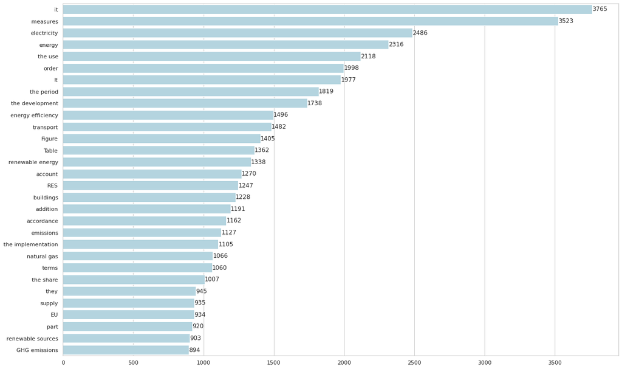

```python
plot_counter(chunk_arr[:30])
plt.show()
```

Wśród najczęstszych chunków, pojawiają się słowa, które uznaliśmy za występujące wyjątkowo często w NECP-ach. Dodatkowo pojawiają się takie frazy jak: 'the developement' - rozwój, 'energy efficiency' - wydajność energetyczna, czy 'RES' - skrót od Renewable Energy Sources.

Przeprowadźmy jeszcze Entity Recognition.

```python
ent_type_list = []
for doc in necp_docs:
  for ent in doc.ents:
      ent_type_list.append((ent.label_))

ent_type_unique, ent_type_counts = np.unique(ent_type_list, return_counts = True)
ent_type_counter = np.c_[ent_type_unique[ent_type_counts.argsort()[::-1]], ent_type_counts[ent_type_counts.argsort()[::-1]]]
```

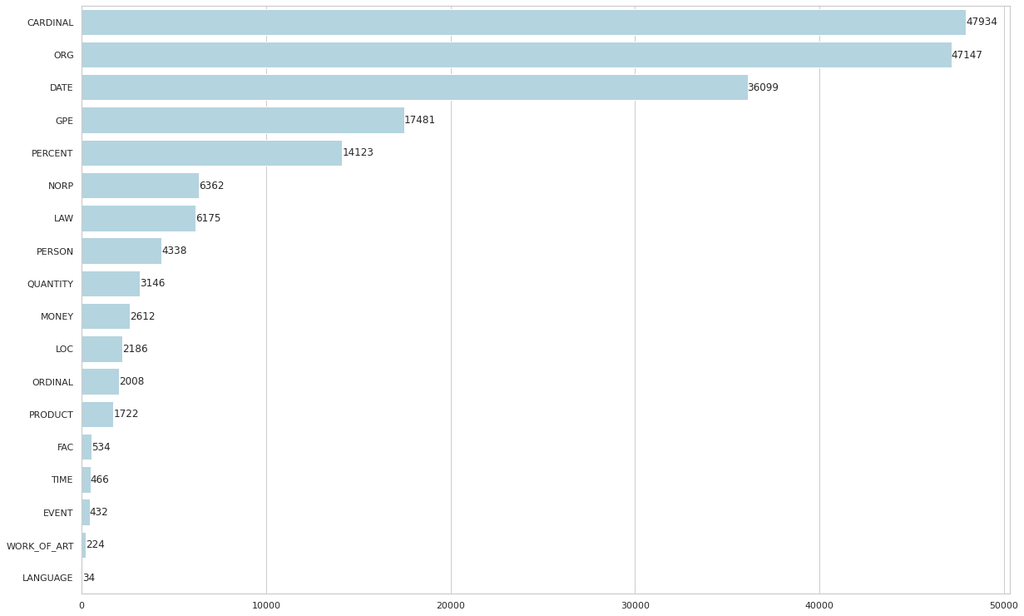

```python
plot_counter(ent_type_counter)
plt.show()
```

W tekstach występuje najwięcej liczb, organizacji, dat i państw.

```python
ents_list = []
for doc in necp_docs:
  for ent in doc.ents:
    if ent.label_ not in ['CARDINAL', 'ORDINAL', 'DATE', 'GPE', 'MONEY', 'PERCENT', 'QUANTITY']:
      ents_list.append((ent.text))

ents_unique, ents_counts = np.unique(ents_list, return_counts = True)
ents_counter = np.c_[ents_unique[ents_counts.argsort()[::-1]], ents_counts[ents_counts.argsort()[::-1]]][:25]
```

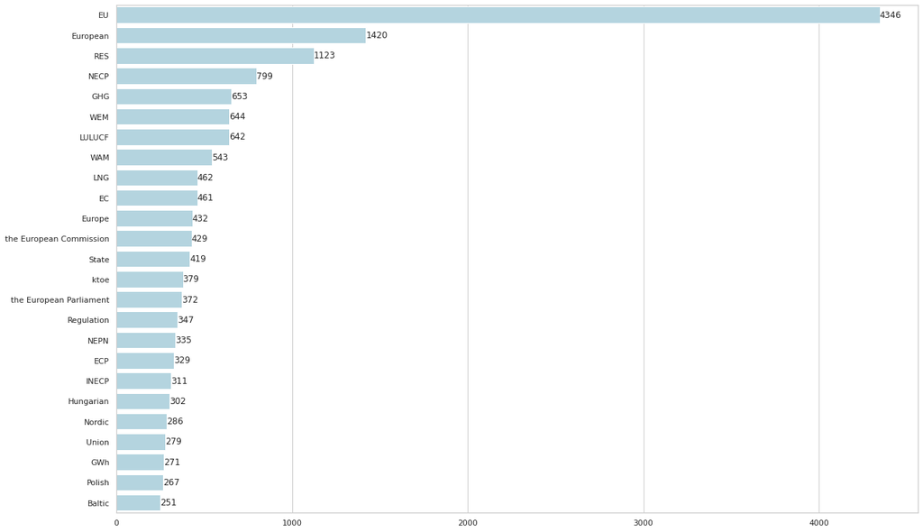

```python
plot_counter(ents_counter)
plt.show()
```

Ponownie bez zaskoczeń. Najczęściej wspominana jest Unia Europejska, odnawialne źródła energii i krajowy plan na rzecz energii i klimatu. Rozszyfrujmy jeszcze inne występujące często skróty.

- GHG - greenhouse gas
- WEM - with existing measures (np. "with existing measures" scenario)
- LULUCF - land use, land use change and forestry
- WAM - with additional measures (np. "with additional measures" scenario)
- LNG - liquefied natural gas
- EC - często występująca część numeracji aktów prawnych Unii Europejskiej. Oznacza dyrektywę wiążącą państwa członkowskie do osiągnięcia pewnego rezultatu. Metody jakimi dane państwo cel osiągnie są dowolne.
- NEPN, INECP - Integrated National Energy and Climate Plan
- ECP - energy and climate policy

Dodatkowo warto zauważyć, że najczęściej wspominane zwroty dotyczące państw/regionów to Hungarian, Nordic, Polish, Baltic.

##### Najpopularniejsze słowa w podziale na sekcje

```python
sections = ["Overview and Process for Establishing the Plan", "National Objectives and Targets", "Policies and Measures",
            "Current Situation and Reference Projections", "Impact Assessment of Planned Policies and Measures"]
sections_counter = {}
for section in sections:
  necp_processed_temp = necp_processed.loc[necp_processed.subsection == section]
  cnt = Counter(necp_processed_temp["necp_lemmas"].sum())
  sections_counter[section] = cnt
```

```python
sections_counter_all = pd.DataFrame()
most_common_words = set()
for key, val in sections_counter.items():
  most_common_words.update({word for word, _ in val.most_common(10)})
```

```python
most_common_words = sorted(list(most_common_words))
```

```python
sections_len = necp_processed.groupby(['subsection']).length.sum()
```

```python
most_common_words_df = pd.DataFrame(columns=["word"]+list(sections_counter.keys()))
most_common_prom_words_df = pd.DataFrame(columns=["word"]+list(sections_counter.keys()))
for word in most_common_words:
  row = {'word':word}
  row2 = {'word':word}
  for section, counter in sections_counter.items():
    row[section] = counter[word]
    row2[section] = 1000*counter[word] / sections_len[section]
  most_common_words_df=most_common_words_df.append(row, ignore_index=True)
  most_common_prom_words_df=most_common_prom_words_df.append(row2, ignore_index=True)
```

**Liczba wystąpień popularnych słów w poszczególnych sekcjach**

- suma zbiorów 10 najpopularniejszych słów w każdej sekcji
- pierwszy wykres liczby wystąpień
- drugi wykres liczby wystąpień w promilach (normowane przez łączną liczbę słów w dokumentach należących do danej sekcji)

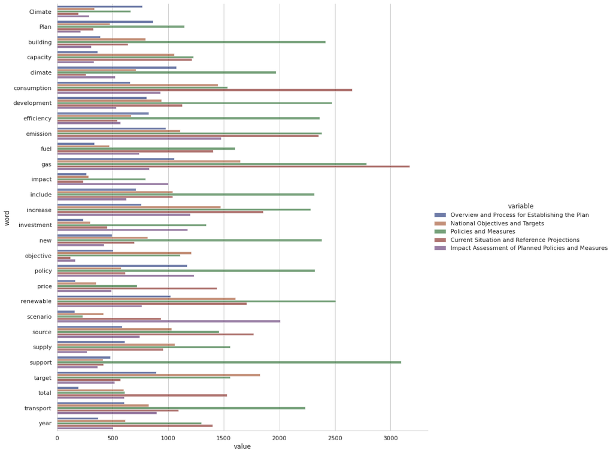

```python
most_common_words_df=most_common_words_df.melt(id_vars="word", value_vars=sections)
sns.catplot(
    data=most_common_words_df, kind="bar",
    y="word", x="value", hue="variable",
    palette="dark", alpha=.6, height=12, orientation="horizontal"
)
plt.show()
```

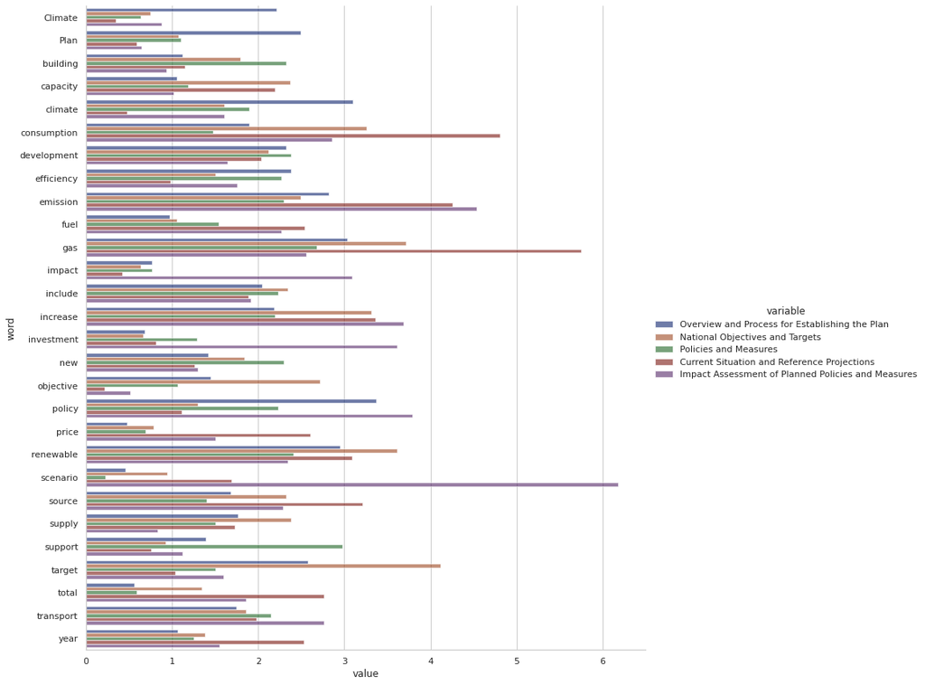

```python
most_common_prom_words_df=most_common_prom_words_df.melt(id_vars="word", value_vars=sections)
sns.catplot(
    data=most_common_prom_words_df, kind="bar",
    y="word", x="value", hue="variable",
    palette="dark", alpha=.6, height=12, orientation="horizontal"
)
plt.show()
```

- można odczytać dość oczywiste rzeczy, jak to, że w sekcji Overview… stosunkowo bardziej popularne będą słowa jak climate czy plan, a w sekcji Impact Assessment… słowo scenario
- widzimy, że climate pojawia się stosunkowo rzadziej w sekcji Current Situation
- słowa consumption i gas są częściej wykorzystywane w sekcjach National Objectives i Current Situation
- słowa emission i fuel są częściej wykorzystywane w sekcjach Current Situation i Impact Assessment
- w sekcji Current Situation and Reference Projections częste jest słowo price
- support jest popularnym słowem w Policies and Measures
- renewable jest częste w National Objectives and Targets

##### Najpopularniejsze słowa w podziale na wymiary

- wykresy analogiczne jak powyżej

```python
dimensions_len = necp_processed.groupby(['energy_union_dimension']).length.sum()
```

```python
dimensions = [ 'Decarbonisation', 'Energy efficiency', 'Energy security', 'Internal market', 'R&I and Competitiveness']

dims_counter = {}
for dim in dimensions:
  necp_processed_temp = necp_processed.loc[necp_processed.energy_union_dimension == dim]
  cnt = Counter(necp_processed_temp["necp_lemmas"].sum())
  dims_counter[dim] = cnt
```

```python
dims_counter_all = pd.DataFrame()
most_common_words = set()
for key, val in dims_counter.items():
  most_common_words.update({word for word, _ in val.most_common(10)})
most_common_words = sorted(list(most_common_words))
most_common_words_df = pd.DataFrame(columns=["word"]+list(dims_counter.keys()))
most_common_prom_words_df = pd.DataFrame(columns=["word"]+list(dims_counter.keys()))
for word in most_common_words:
  row = {'word':word}
  row2 = {'word':word}
  for section, counter in dims_counter.items():
    row[section] = counter[word]
    row2[section] = 1000*counter[word] / dimensions_len[section]
  most_common_words_df=most_common_words_df.append(row, ignore_index=True)
  most_common_prom_words_df=most_common_prom_words_df.append(row2, ignore_index=True)
```

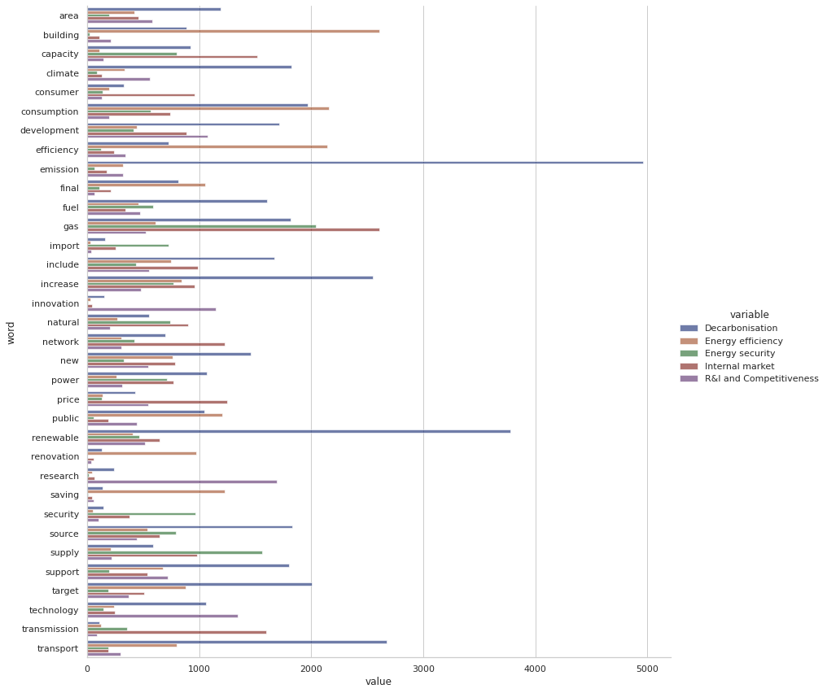

```python
most_common_words_df=most_common_words_df.melt(id_vars="word", value_vars=dimensions)
sns.catplot(
    data=most_common_words_df, kind="bar",
    y="word", x="value", hue="variable",
    palette="dark", alpha=.6, height=12, orientation="horizontal"
)
plt.show()
```

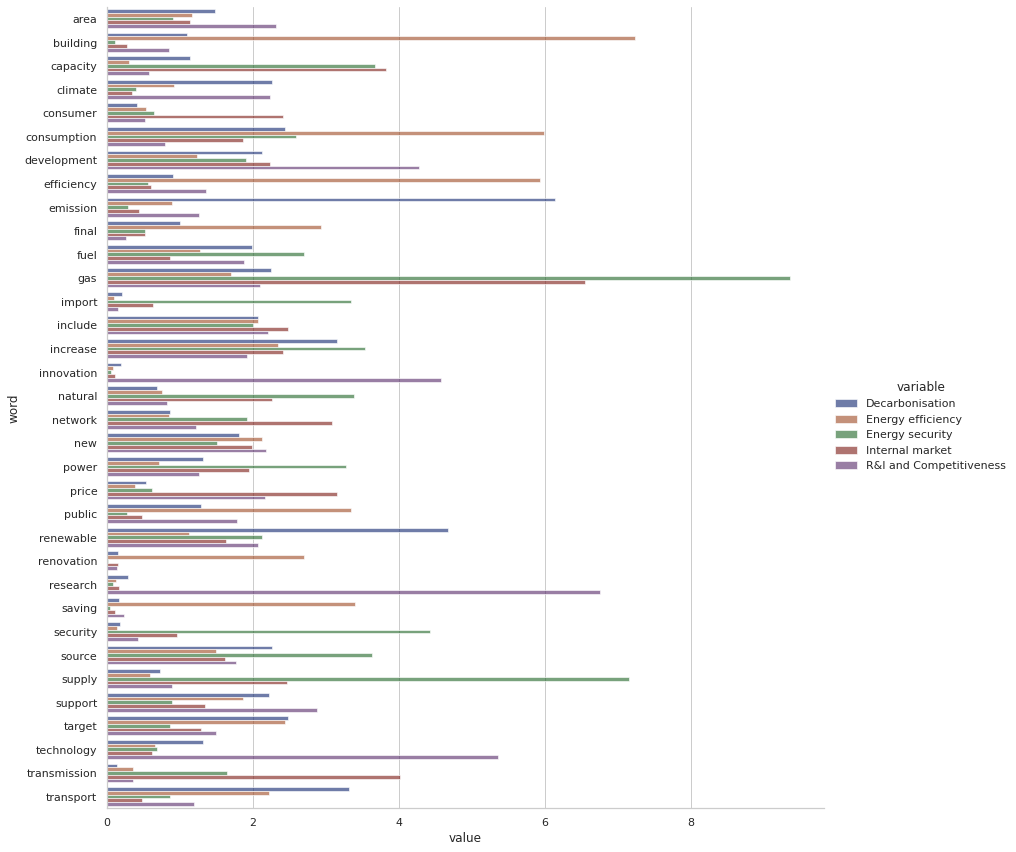

```python
most_common_prom_words_df=most_common_prom_words_df.melt(id_vars="word", value_vars=dimensions)
sns.catplot(
    data=most_common_prom_words_df, kind="bar",
    y="word", x="value", hue="variable",
    palette="dark", alpha=.6, height=12, orientation="horizontal"
)
plt.show()
```

W wymiarze obniżenia emisyjności dominują słowa: 'emission', 'renewable' i 'transport'. Możemy się domyślać, że państwa w dużej mierze planują obniżenie emisyjności w sektorze transportu.  
W wymiarze efektywności energetycznej pojawiają się takie słowa jak: 'building', 'public', 'renovation'. Może to sugerować potrzebę nowych inwestycji.  
W wymiarze bezpieczeństwa energetycznego ze specyficznych słów pojawiają się: 'natural' i 'capacity'.  
W wymiarze wewnętrznego rynku energii pojawiają się takie słowa jak: 'gas', 'transmission', 'network', 'supply'. W sekcji prawdopodbnie zawarte są informacje o transmisji energii.  
W wymiarze badań naukowych, innowacji i konkurencyjności znajdują się słowa w znacznym stopniu pasujące do tematu: 'research', 'technology', 'innovation', 'development', 'new'.

##### Analiza w podziale na kraje

```python
necp_processed.groupby(['country']).length.sum().sort_values(ascending=False)
```

```
country
Belgium        212404
Poland         182453
Italy          140538
France         137362
Czechia        126128
Spain          120611
Slovakia       116771
Bulgaria       109821
Lithuania      109428
Germany        108556
Portugal       104145
Cyprus          96040
Croatia         93867
Ireland         92260
Austria         87293
Netherlands     87118
Romania         85414
Malta           84527
Greece          81261
Hungary         81222
Slovenia        80590
Estonia         69206
Sweden          68767
Denmark         66921
Luxembourg      62852
Finland         50849
Latvia          49120
Name: length, dtype: int64
```

Państwa, które stworzyły najdłuższe NECP-y to Belgia i Polska. Najkrótsze dokumenty pochodzą z Łotwy i Finlandii.

```python
countries = sorted(necp_processed["country"].unique())

for country in countries:
  necp_processed_temp = necp_processed.loc[necp_processed.country == country]
  cnt = Counter(necp_processed_temp["necp_lemmas"].sum()).most_common(7)
  print(country)
  for i in range(7):
    print(cnt[i])
```

```
Austria
('Austria', 562)
('Climate', 360)
('renewable', 359)
('Plan', 320)
('National', 304)
('Integrated', 254)
('increase', 250)
Belgium
('building', 664)
('emission', 561)
('support', 516)
('public', 505)
('consumption', 505)
('policy', 502)
('climate', 491)
Bulgaria
('gas', 563)
('emission', 542)
('source', 473)
('renewable', 448)
('Bulgaria', 434)
('consumption', 368)
('increase', 344)
Croatia
('gas', 446)
('emission', 410)
('development', 342)
('implementation', 340)
('Croatia', 330)
('increase', 291)
('building', 281)
Cyprus
('Cyprus', 434)
('cost', 330)
('emission', 324)
('scenario', 306)
('building', 265)
('transport', 259)
('gas', 253)
```

[output cut: 161 more lines]

```
('renewable', 566)
('consumption', 329)
('gas', 327)
('public', 301)
('increase', 264)
('efficiency', 260)
('Spain', 249)
Sweden
('Sweden', 293)
('climate', 241)
('renewable', 235)
('emission', 225)
('policy', 207)
('target', 194)
('Swedish', 191)
```

W zdecydowanej większośći krajów jednym z najpopularniejszych słów jest właśnie nazwa kraju. Poza tym bardzo często występują takie frazy jak wcześniej ('gas', 'climate', 'renewable', 'policy' itp.). Ciężko wyciągnąć z tego sensowne wnioski.

```python
most_common_words_to_exlude = list(dict(necp_lemmas_counter2.most_common(30)).keys())
for country in countries:
  necp_processed_temp = necp_processed.loc[necp_processed.country == country]
  cnt = Counter(necp_processed_temp["necp_lemmas"].sum()).most_common()
  print(country)
  count = 0
  i = 0
  while count < 7:
    if cnt[i][0] not in most_common_words_to_exlude:
      print(cnt[i])
      count+=1
    i+=1
```

```
Austria
('Austria', 562)
('Climate', 360)
('Plan', 320)
('National', 304)
('Integrated', 254)
('Federal', 188)
('Act', 175)
Belgium
('develop', 423)
('term', 403)
('renovation', 365)
('order', 338)
('investment', 317)
('need', 315)
('business', 310)
Bulgaria
('Bulgaria', 434)
('period', 290)
('plant', 265)
('natural', 244)
('transmission', 243)
('set', 233)
('generation', 226)
Croatia
('implementation', 340)
('Croatia', 330)
('Republic', 259)
('period', 231)
('activity', 230)
('fund', 225)
('transmission', 216)
Cyprus
('Cyprus', 434)
('cost', 330)
('RES', 202)
('investment', 188)
('period', 174)
('PPM', 159)
('generation', 140)
```

[output cut: 161 more lines]

```
('Spain', 249)
('generation', 245)
('Plan', 233)
('objective', 216)
('promote', 212)
('action', 187)
('network', 173)
Sweden
('Sweden', 293)
('Swedish', 191)
('tax', 184)
('Agency', 137)
('Government', 135)
('price', 133)
('carbon', 114)
```

Pomijając 30 najpopulaniejszych słów widać już więcej różnic między państwami, co jest dobrym znakiem przed modelowaniem tematów i próbą znalezienia istotnych różnic pomiędzy planami poszczególnych państw członkowskich.

#### Analiza n-gramów

Więcej kontekstu w to, o czym jest mowa w analizowanych tekstach daje nam analiza digramów i trigramów.

##### digramy

```python
from sklearn.feature_extraction.text import CountVectorizer
```

```python
cv = CountVectorizer(stop_words = en.Defaults.stop_words, ngram_range=(2, 2))
count_vector = cv.fit_transform(necp_processed['text'].values)
sum_ngram = count_vector.sum(axis=0)
ngram_freq = [(ngram, sum_ngram[0, idx])
              for ngram, idx in cv.vocabulary_.items()]
ngram_freq = sorted(ngram_freq, key = lambda x: x[1], reverse=True)
```

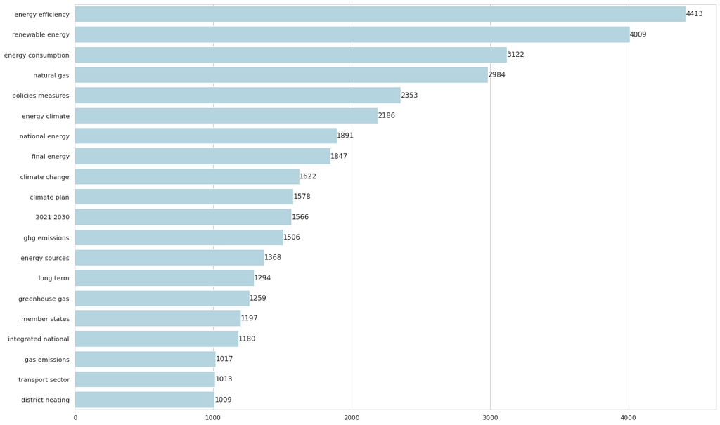

```python
plot_counter(ngram_freq[:20])
plt.show()
```

##### trigramy

```python
cv3 = CountVectorizer(stop_words = en.Defaults.stop_words, ngram_range=(3, 3))
count_vector3 = cv3.fit_transform(necp_processed['text'].values)
sum_ngram3 = count_vector3.sum(axis=0)
ngram_freq3 = [(ngram, sum_ngram3[0, idx])
              for ngram, idx in cv3.vocabulary_.items()]
ngram_freq3 = sorted(ngram_freq3, key = lambda x: x[1], reverse=True)
```

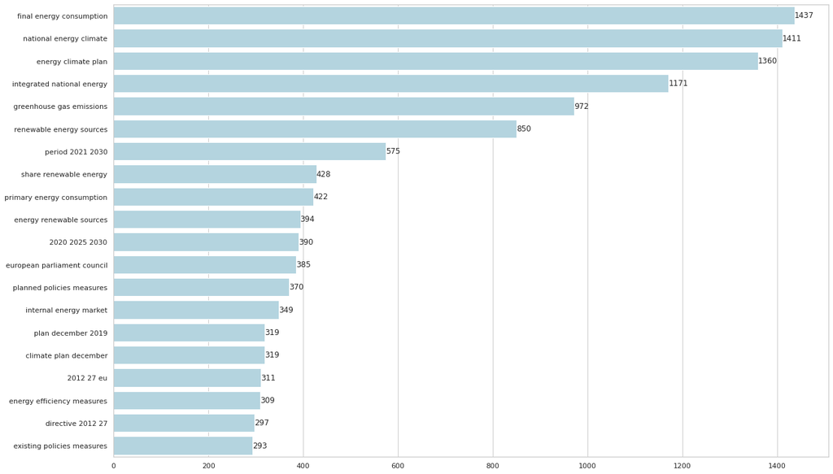

```python
plot_counter(ngram_freq3[:20])
plt.show()
```

Oprócz oczywistych wniosków o bliższym kontekście analizowanych tekstów, można zauważyć, że:

- Na wykresach pojawiają się np. ważne horyzonty czasowe związane z Zielonym Ładem.
- Potwierdzają się przypuszczenia o pojawianiu się słowa 'gas' w dwóch kontekstach.

### Spoza kamienia milowego - przykład modelowania

```python
from gensim.corpora.dictionary import Dictionary
from gensim.models.ldamulticore import LdaMulticore
necp_processed['lemmas'] = necp_docs.apply(lambda d: [t.lemma_ for t in d if not t.is_stop if t.is_alpha])
dictionary = Dictionary(necp_processed['lemmas'])
encoded_docs = necp_processed['lemmas'].apply(dictionary.doc2bow)
```

```python
lda = LdaMulticore(encoded_docs, num_topics=6)
```

```python
!pip install pyLDAvis
```

```python
import pyLDAvis.gensim_models
pyLDAvis.enable_notebook()
vis = pyLDAvis.gensim_models.prepare(lda, encoded_docs, dictionary=dictionary)
vis
```

[interactive chart not shown]

```python
!jupyter nbconvert --to html "/content/drive/MyDrive/NLP-klimat/eda1_necps.ipynb"
```

```
[NbConvertApp] Converting notebook /content/drive/MyDrive/NLP-klimat/eda1_necps.ipynb to html
[NbConvertApp] Writing 1387301 bytes to /content/drive/MyDrive/NLP-klimat/eda1_necps.html
```